# Understanding Regression with code

# 1 Make toy data

1. X: N X p 개의 정규화된 Input Data를 생성한다.
2. b: p개의 변수의 coefficient가 될 , True 값을 설정한다.
3. y: 데이터 X에서 b에서 설정한 coefficient가 나올 수 있도록 y값을 생성한다.

즉, y ~ X를 예측했을 때, 각 변수의 coefficient는 b에 가까워야 한다.

```r
set.seed(1050)
N <- 300
p <- 6
X <- scale(matrix(rnorm(N*p), ncol=p))
b <- c(.5, -.5, .25, -.25,  0, 0)
y <- scale(X %*% b + rnorm(N, sd=.5))
```

```r
head(data.frame(y=y, X=X))
```

|  | y | X.1 | X.2 | X.3 | X.4 | X.5 | X.6 |
| --- | --- | --- | --- | --- | --- | --- | --- |
| 1 | 0.4770188 | -0.29945550 | -0.5909616 | -0.43705270 | -1.005921840 | 1.7151550 | 0.36415446 |
| 2 | 0.9860820 | 0.01172597 | 0.1237334 | -0.94562438 | -3.518582438 | 0.1241835 | 0.04544830 |
| 3 | -0.4752091 | 0.37148667 | 0.1313717 | 0.77794474 | -0.008952998 | 0.8986408 | -0.06556294 |
| 4 | 0.4218687 | -0.42584875 | -2.0111916 | -0.05507761 | 0.495724322 | 0.2215569 | 1.22140524 |
| 5 | -0.4913127 | 0.45122767 | 0.9078340 | -0.17217952 | 0.823632650 | -0.1429232 | -0.09199726 |
| 6 | 2.1947373 | 2.42714909 | 0.2012683 | -0.26415291 | -0.176101354 | -0.5538475 | 0.39518425 |

# 2 Linear Regression

## 2.1 use lm function in R package

```r
lr_pack <- lm(y ~ .-1, data=data.frame(X=X, y=y))
lr_pack$coefficients
```

```
        X.1         X.2         X.3         X.4         X.5         X.6
 0.57728733 -0.52511348  0.17856262 -0.27332295  0.00753157 -0.01573829
```

## 2.2 use OLS (ordinary least squares)

$\hat \beta = {({X^T}X)^{ - 1}}{X^T}y$

```r
lr_ols <- solve(crossprod(X)) %*% crossprod(X, y)
as.numeric(lr_ols)
```

```
[1]  0.57728733 -0.52511348  0.17856262 -0.27332295  0.00753157 -0.01573829
```

## 2.3 use Optimization

### 2.3.1 set loss function

$\min {(y - \beta X)^2}$

```r
lr_loss <- function(w, X, y) {
    crossprod(y - X%*%w)
}
```

### 2.3.2 optimization

`optim` function 사용.  
첫 번째 파라미터는 beta의 초기 값. 변수 길이 만큼 셋팅. 아래는 0으로 세팅.  
두 번째 파라미터는 위에서 설정한 loss function.  
세,네 번째 파라미터는 각각 Input, Output.  
다섯 번째 파라미터 method는 최적화 알고리즘. 아래 BFGS는 뉴턴메소드로 알려져 있음.

```r
lr_optim <- optim(rep(0, ncol(X)), lr_loss, X=X, y=y, method='BFGS')
lr_optim$par
```

```
[1]  0.57728733 -0.52511348  0.17856262 -0.27332295  0.00753157 -0.01573829
```

# 3 Ridge Regression

## 3.1 use glmnet function in R glmnet package

`glmnet` 함수의 alpha가 0이면 ridge regression 1이면 lasso regression을 사용한다.  
lambda는 여러 lambda 값을 입력해서 모델을 생한하고 최적의 lambda 값을 선택한다.

```r
library(glmnet)
glmnet_ridge <- glmnet(X, y, alpha=0, lambda=c(10, 1, .1), intercept=F)
as.numeric(coef(glmnet_ridge, s=.1))[-1]
```

```
[1]  0.525895400 -0.476359033  0.163947016 -0.244474844  0.006063986 -0.001999365
```

## 3.2 use Optimization

### 3.2.1 set loss function

$\min {(y - \beta X)^2} + \lambda n\sum\limits_i {\beta_i^2}$

```r
ridge_loss <- function(w, X, y, lambda = .1) {
  crossprod(y - X%*%w) + lambda*length(y)*crossprod(w)
}
```

### 3.2.2 optimization

```r
ridge_optim <- optim(rep(0, ncol(X)), ridge_loss, X=X, y=y, lambda=.1, method = 'BFGS')
ridge_optim$par
```

```
[1]  0.525817454 -0.476285331  0.163924638 -0.244431737  0.006061954 -0.001980449
```

## 3.3 use OLS (ordinary least squares)

$\hat \beta = {({X^T}X + \lambda nI)^{ - 1}}{X^T}y$

```r
ridge_ols <- solve(crossprod(X) + diag(length(y)*.1, ncol(X))) %*% crossprod(X, y)
as.numeric(ridge_ols)
```

```
[1]  0.525817454 -0.476285331  0.163924638 -0.244431738  0.006061954 -0.001980449
```

## 3.4 change coefficient according to the change of lambda

$X^TX$

```r
crossprod(X)
```

```
            [,1]      [,2]       [,3]        [,4]       [,5]      [,6]
[1,] 299.0000000 -14.11386  18.597360  -0.8492448  -9.379009  42.67402
[2,] -14.1138619 299.00000   2.017060 -22.8894375 -10.380211 -26.30647
[3,]  18.5973597   2.01706 299.000000   4.5832707 -18.453962  11.49866
[4,]  -0.8492448 -22.88944   4.583271 299.0000000  -9.441783 -12.96481
[5,]  -9.3790090 -10.38021 -18.453962  -9.4417831 299.000000  20.66621
[6,]  42.6740191 -26.30647  11.498657 -12.9648114  20.666211 299.00000
```

$X^TX + \lambda nI$

```r
print(length(y)*.1)
```

```
[1] 30
```

```r
crossprod(X) + diag(length(y)*.1, ncol(X))
```

```
            [,1]      [,2]       [,3]        [,4]       [,5]      [,6]
[1,] 329.0000000 -14.11386  18.597360  -0.8492448  -9.379009  42.67402
[2,] -14.1138619 329.00000   2.017060 -22.8894375 -10.380211 -26.30647
[3,]  18.5973597   2.01706 329.000000   4.5832707 -18.453962  11.49866
[4,]  -0.8492448 -22.88944   4.583271 329.0000000  -9.441783 -12.96481
[5,]  -9.3790090 -10.38021 -18.453962  -9.4417831 329.000000  20.66621
[6,]  42.6740191 -26.30647  11.498657 -12.9648114  20.666211 329.00000
```

change $\lambda$ 0.1 to 1

```r
print(length(y)*1)
```

```
[1] 300
```

```r
crossprod(X) + diag(length(y)*1, ncol(X))
```

```
            [,1]      [,2]       [,3]        [,4]       [,5]      [,6]
[1,] 599.0000000 -14.11386  18.597360  -0.8492448  -9.379009  42.67402
[2,] -14.1138619 599.00000   2.017060 -22.8894375 -10.380211 -26.30647
[3,]  18.5973597   2.01706 599.000000   4.5832707 -18.453962  11.49866
[4,]  -0.8492448 -22.88944   4.583271 599.0000000  -9.441783 -12.96481
[5,]  -9.3790090 -10.38021 -18.453962  -9.4417831 599.000000  20.66621
[6,]  42.6740191 -26.30647  11.498657 -12.9648114  20.666211 599.00000
```

**why?**  
normalized된 벡터의 내적은 왜 항상 n-1 이 되는가??

```r
a <- scale(rnorm(100))
print(crossprod(a))
```

```
     [,1]
[1,]   99
```

```r
b <- scale(runif(50))
print(crossprod(b))
```

```
     [,1]
[1,]   49
```

**anwser**  
sample 된 표본 X의 분산은 $Var(X) = \sum\limits_i {{{({x_i} - \bar X)}^2}} /(n - 1)$ 이다.  
위 a는 X의 $a = (X - \bar X)/sd(X)$ 로 scale된 값이다.  
a의 crossproduct는 ${a^T}a = \sum\limits_i {{{({x_i} - \bar X)}^2}} /sd{(X)^2}$ 이다.  
$sd{(X)^2} = Var(X)$ 때문에, ${a^T}a = n-1$이 된다.

inverse of matrix  
$\lambda$ 0.1

```r
solve(crossprod(X) + diag(length(y)*.1, ncol(X)))
```

```
              [,1]          [,2]          [,3]          [,4]          [,5]          [,6]
[1,]  3.107341e-03  1.063936e-04 -1.564764e-04  5.115186e-06  1.081633e-04 -0.0003956645
[2,]  1.063936e-04  3.081861e-03 -3.129879e-05  2.270505e-04  9.014132e-05  0.0002370010
[3,] -1.564764e-04 -3.129879e-05  3.062341e-03 -4.433230e-05  1.714410e-04 -0.0001017522
[4,]  5.115186e-06  2.270505e-04 -4.433230e-05  3.063659e-03  8.429798e-05  0.0001344742
[5,]  1.081633e-04  9.014132e-05  1.714410e-04  8.429798e-05  3.070187e-03 -0.0002023466
[6,] -3.956645e-04  2.370010e-04 -1.017522e-04  1.344742e-04 -2.023466e-04  0.0031313509
```

$\lambda$ 1

```r
solve(crossprod(X) + diag(length(y)*1, ncol(X)))
```

```
              [,1]          [,2]          [,3]          [,4]          [,5]          [,6]
[1,]  1.680691e-03  3.516282e-05 -4.913578e-05  2.008969e-06  2.952197e-05 -1.182235e-04
[2,]  3.516282e-05  1.676467e-03 -7.759885e-06  6.616461e-05  2.793126e-05  7.173822e-05
[3,] -4.913578e-05 -7.759885e-06  1.673283e-03 -1.302883e-05  5.151146e-05 -3.102051e-05
[4,]  2.008969e-06  6.616461e-05 -1.302883e-05  1.673317e-03  2.582969e-05  3.833903e-05
[5,]  2.952197e-05  2.793126e-05  5.151146e-05  2.582969e-05  1.674428e-03 -5.907606e-05
[6,] -1.182235e-04  7.173822e-05 -3.102051e-05  3.833903e-05 -5.907606e-05  1.684486e-03
```

[1,1] 값에서 $\lambda$의 값이 0.1에서 1로 변하면서 1.8488473배 줄어들었지만,  
[1,2] 값에서는 3.0257414배 감소하였다. [1,3]에서는 3.1845714 줄어들었다.  
각 weigth 들이 일정하게 증감하지 않는다. 하지만 $\lambda$가 커짐에 따라 0 방향으로 감소한다.

```r
crossprod(X, y)
```

```
            [,1]
[1,]  182.830947
[2,] -158.204464
[3,]   61.494390
[4,]  -69.242935
[5,]    1.248563
[6,]   39.495766
```

```r
lamda.1 <- solve(crossprod(X) + diag(length(y)*.1, ncol(X)))  %*% crossprod(X, y)
as.numeric(lamda.1)
```

```
[1]  0.525817454 -0.476285331  0.163924638 -0.244431738  0.006061954 -0.001980449
```

```r
lamda <- solve(crossprod(X) + diag(length(y)*1, ncol(X)))  %*% crossprod(X, y)
as.numeric(lamda)
```

```
[1]  0.293926211 -0.260986045  0.094882908 -0.125220329  0.002115196  0.028929772
```

```r
as.numeric(lamda.1 / lamda)
```

```
[1]  1.78894374  1.82494559  1.72765193  1.95201323  2.86590636 -0.06845713
```

### 3.4.1 understanding lamda and t

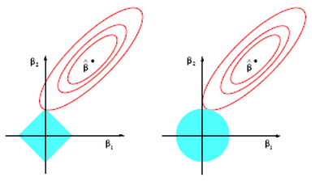

$\hat \beta = {({X^T}X + \lambda nI)^{ - 1}}{X^T}y$  
위 식에서 $\lambda$가 0이면 일반 linear regression의 베타 해를 구하는 식과 동일해 진다.  
그리고 $\lambda$를 키우면 앞의 식의 갚을 키우고 Inverse 함으로 전체 값(베타)이 줄어 든다.  
**But**  
위 그림에서 제약식인 동그란 원이 커지면 $\beta$ 값이 커지고 원이 작아지면 $\beta$ 값이 0에 가까워 져야 한다.  
위 식에서 이해한 상식과 반대로 작동한다.  
**what is the problem?**  
위 식에서 $\lambda$가 그림에서 원의 크고 작음을 나타내지 않는다.  
**understanding lamda & t**  
ridge의 최초 minimize 식을 생각하면 다음과 같다.  
$\min {(y - \beta X)^2}/n$ subject to $\sum\limits_i {{\beta _i}^2} < t$  
위 식은 다시 lagrangian에 의해 다음과 동일하게 된다.  
$\min {(y - \beta X)^2}/n - \lambda (t - \sum {{\beta ^2}} )$  
=> $\min {(y - \beta X)^2}/n + \lambda (\sum {{\beta ^2} - t} )$  
derivative $\beta = {({X^T}X + \lambda nI)^{ - 1}}{X^T}y$  
$\beta$ 값을 생각했을 때, $\lambda$ 값이 0에 가까워지면, 일반 linear regression 식과 동일해진다.  
반대로 $\lambda$ 값을 키우면 식의 오른쪽 텀의 값이 커지고 역함수가 되기 때문에 $\beta$ 값은 줄어들게 된다.  
이번엔 제약식에서 t 값을 높인다면 $\beta$ 값이 커지고, t 값이 0에 가까워 지면 beta 값이 작아진다.  
즉, $\lambda$ 값을 키우는 것이 t 값을 줄이는 것과 같은 효과를 보이고 $\lambda$ 줄이는 것이 t 값을 높이는 것과 같아 진다.

# 4 Lasso Regression

## 4.1 use glmnet function in R glmnet package

`glmnet` 함수의 alpha가 0이면 ridge regression 1이면 lasso regression을 사용한다.  
$\lambda$는 여러 $\lambda$ 값을 입력해서 모델을 생성하고 최적의 $\lambda$ 값을 선택한다.

```r
library(glmnet)
glmnet_lasso <- glmnet(X, y, alpha=1, lambda=c(10, 1, .1), thresh=1e-12, intercept=F)
as.numeric(coef(glmnet_lasso, s=.1))[-1]
```

```
[1]  0.48604990 -0.41905020  0.08059903 -0.16334927  0.00000000  0.00000000
```

## 4.2 use Optimization

### 4.2.1 set loss function

$\min {(y - \beta X)^2} + \lambda n\sum\limits_i {abs({\beta _i})}$

```r
lasso_loss <- function(w, X, y, lambda = .1) {
  crossprod(y - X%*%w) + lambda*length(y)*sum(abs(w))
}
```

### 4.2.2 optimization

```r
lasso_optim <- optim(rep(0, ncol(X)), lasso_loss, X=X, y=y, lambda=.1, method = 'BFGS')
lasso_optim$par
```

```
[1]  5.303173e-01 -4.714461e-01  1.290249e-01 -2.179064e-01  1.060926e-04  5.093336e-07
```

lasso의 경우 정규화(제약)텀이 미분되지 않기 때문에 OLS 방법으로 해를 구할 수 없다.  
그리고 일반적으로 나타내는 lasso_loss 식을 통해 일반적으로 사용되는 최적화 식으로 풀었을 때,  
lasso package에서 작동하는 방식으로 동작하지는 않는다.  
lasso의 $\beta$ 해를 구하는 방법이 일반적인 방법과 다른 방법으로 풀어야 한다. ([참조](http://statweb.stanford.edu/~tibs/sta305files/Rudyregularization.pdf))

# 5 Ordianl Regression (cumulative link model)

(참조: [Cumulative Link Models for Ordinal Regression with the R Package ordinal](https://cran.r-project.org/web/packages/ordinal/vignettes/clm_article.pdf))

## 5.1 Make toy data

```r
set.seed(1050)
N <- 1000                                       # 샘플 수
x <- cbind(x1 = rnorm(N), x2 = rnorm(N))        # 두개의 랜덤노말 변수 생성
beta <- c(1,-1)                                 # coefficients
y_star <- rnorm(N, mean=x %*% beta)             # true y (1*x1 + -1*x2)
y_1 <- y_star > -1.5                            # -1.5 theta 1
y_2 <- y_star > .75                             # .75 theta 2
y_3 <- y_star > 1.75                            # 1.75 theta 3
y <- y_1 + y_2 + y_3 + 1                        # target
df <- data.frame(x, y=factor(y))
```

labeling

1. y <= -1.5
2. -1.5 < y <= 0.75
3. 0.75 < y <= 1.75
4. y > 1.75

distribution of y

```r
table(y)
```

```
y
  1   2   3   4
192 470 175 163
```

## 5.2 use clm function in R ordinal package

```r
library(ordinal)
clm_pack_probit = clm(y ~ x1 + x2, data=df, link='probit')
clm_pack_logit  = clm(y ~ x1 + x2, data=df, link='logit')
```

```r
print("probit link:")
```

```
[1] "probit link:"
```

```r
print(coef(clm_pack_probit))
```

```
       1|2        2|3        3|4         x1         x2
-1.4219541  0.7630781  1.7539626  1.0358997 -0.9415468
```

```r
cat('\n')
```

```r
print("logit link:")
```

```
[1] "logit link:"
```

```r
print(coef(clm_pack_logit))
```

```
      1|2       2|3       3|4        x1        x2
-2.531062  1.309862  3.044498  1.821067 -1.665129
```

## 5.3 use Optimization

```r
probit=T
pfun = ifelse(probit, pnorm, plogis)
K = length(unique(y))
ncuts = K-1
par = c(-1,1,2,0,0)
cuts = par[(1:ncuts)]
beta = par[-(1:ncuts)]
```

1. probit & pfun
   - link function을 선택한다.
   - probit이 True라면 정규분포를 사용하고 False라면 logistic 분포를 사용한다.
2. K & ncuts
   - K는 ordinal label의 길이고 ncuts은 ordinal parameter 수이다.
3. par: 초기 파라미터를 설정한다.
   - [cuts] + [beta]
   - cuts: 위 예에서 라벨의 길이는 4(1,2,3,4) 이기 때문에 3개(theta1, 2, 3)의 파라미터를 설정한다.
   - beta: 변수(피처)의 개수는 2개이기 때문에 2개의 파라미터를 설정한다.

y_h: linear calculate ( beta1*x1 + beta2*x2 )

```r
y_h = x %*% beta
print(head(y_h))
```

```
     [,1]
[1,]    0
[2,]    0
[3,]    0
[4,]    0
[5,]    0
[6,]    0
```

ll: log-likelihood

```r
ll = rep(0, length(y))
print(head(ll))
```

```
[1] 0 0 0 0 0 0
```

γij = F(ηij), ηij = θj − x⊤iβ  
γij = P(Yi ≤ j) = πi1 + . . . + πij with sum(πij) = 1

j=1 일때, ηi1 = -1 - x^t %% beta  
j=2 일때, ηi2 = 1 - x^t %% beta  
j=3 일때, ηi3 = 2 - x^t %*% beta

j=1, γi1 = P(Yi ≤ 1) = F(ηi1)  
j=2, γi2 = P(Yi ≤ 2) = F(ηi2) - F(ηi1)  
j=3, γi3 = P(Yi ≤ 3) = F(ηi3) - F(ηi2)  
j=4, γi4 = P(Yi ≤ 4) = 1 - F(ηi3)

```r
g1 <- pfun((cuts[1] - lp))
g2 <- pfun(cuts[2] - lp) - pfun(cuts[2-1] - lp)
g3 <- pfun(cuts[3] - lp) - pfun(cuts[3-1] - lp)
g4 <- 1 - pfun(cuts[4-1] - lp)
```

```r
print(a1[1:5])
```

```
[1] 0.1586553 0.1586553 0.1586553 0.1586553 0.1586553
```

```r
print(a2[1:5])
```

```
[1] 0.6826895 0.6826895 0.6826895 0.6826895 0.6826895
```

```r
print(a3[1:5])
```

```
[1] 0.1359051 0.1359051 0.1359051 0.1359051 0.1359051
```

```r
print(a4[1:5])
```

```
[1] 0.02275013 0.02275013 0.02275013 0.02275013 0.02275013
```

```r
print(a1[1:5] + a2[1:5] + a3[1:5] + a4[1:5])
```

```
[1] 1 1 1 1 1
```

**likelihood: multiply( yij_h ^ yij )**  
**log-likelihood: sum_i( sum_j( yij * log(yij_h) ))**  
**=> sum_i( yi * log(yi_h) ) (j는 같은 label에서 1이고 나머지는 0이기 때문에)**

code로 다시쓰면 아래와 같다.

```r
for(k in 1:K) {
    if (k==1) {
      ll[y==k] = pfun((cuts[k] - lp[y==k]), log = TRUE)
    }
    else if (k < K) {
      ll[y==k] = log(pfun(cuts[k] - lp[y==k]) - pfun(cuts[k-1] - lp[y==k]))
    }
    else {
      ll[y==k] = log(1 - pfun(cuts[k-1] - lp[y==k]))
    }
}
loss <- -sum(ll)
```

loss function으로 다음과 같이 묶을 수 있다.

```r
clm_loss = function(par, X, y, probit=T) {
  K = length(unique(y))
  ncuts = K-1
  cuts = par[(1:ncuts)]
  beta = par[-(1:ncuts)]
  lp = X %*% beta
  ll = rep(0, length(y))
  pfun = ifelse(probit, pnorm, plogis)

  for(k in 1:K){
    if (k==1) {
      ll[y==k] = pfun((cuts[k] - lp[y==k]), log = TRUE)
    }
    else if (k < K) {
      ll[y==k] = log(pfun(cuts[k] - lp[y==k]) - pfun(cuts[k-1] - lp[y==k]))
    }
    else {
      ll[y==k] = log(1 - pfun(cuts[k-1] - lp[y==k]))
    }
  }
  return(-sum(ll))
}
```

optimization

```r
par = c(-1,1,2,0,0)
clm_optim_probit = optim(par, clm_loss, y = y, X = x, probit=T,control=list(reltol=1e-10))
clm_optim_logit  = optim(par, clm_loss, y = y, X = x, probit=F,control=list(reltol=1e-10))
```

```r
print("probit link:")
```

```
[1] "probit link:"
```

```r
print(clm_optim_probit$par)
```

```
[1] -1.4219547  0.7630519  1.7539370  1.0358854 -0.9415409
```

```r
cat('\n')
```

```r
print("logit link:")
```

```
[1] "logit link:"
```

```r
print(clm_optim_logit$par)
```

```
[1] -2.531073  1.309868  3.044380  1.821065 -1.665142
```

이전 clm 함수의 결과와 비교해 보자

```r
print("probit link:")
```

```
[1] "probit link:"
```

```r
print(coef(clm_pack_probit))
```

```
       1|2        2|3        3|4         x1         x2
-1.4219541  0.7630781  1.7539626  1.0358997 -0.9415468
```

```r
cat('\n')
```

```r
print("logit link:")
```

```
[1] "logit link:"
```

```r
print(coef(clm_pack_logit))
```

```
      1|2       2|3       3|4        x1        x2
-2.531062  1.309862  3.044498  1.821067 -1.665129
```

## 5.4 Interpretation

```r
pred <- predict(clm_pack_logit, newdata = subset(df, select = -y))$fit
```

```r
head(cbind(x, y,pred))
```

```
           x1          x2 y            1           2          3          4
1 -0.29581307  0.06373401 2 0.1316735851 0.744282720 0.09966390 0.02437979
2  0.02599988  0.58904820 3 0.1683216723 0.735754147 0.07754509 0.01837909
3  0.39805176  0.66498035 2 0.1044561874 0.740065030 0.12401342 0.03146536
4 -0.42652453  0.38387424 2 0.2469152315 0.691616252 0.05004315 0.01142537
5  0.48051710  1.09215468 2 0.1697305484 0.735211646 0.07685881 0.01819899
6  2.52394565 -1.17750831 4 0.0001129967 0.005122132 0.02372413 0.97104074
```

```r
beta_h <- coef(clm_pack_logit)[4:5]
y_h <- x %*% beta_h
head(y_h)
```

```
           [,1]
[1,] -0.6448207
[2,] -0.9334935
[3,] -0.3823990
[4,] -1.4159297
[5,] -0.9435243
[6,]  6.5569766
```

```r
theta <- coef(clm_pack_logit)[1:3]
p0_1 <- 1 / (1 + exp(-(theta[1] - y_h)))
p0_2 <- 1 / (1 + exp(-(theta[2] - y_h)))
p0_3 <- 1 / (1 + exp(-(theta[3] - y_h)))
p1 <- p0_1
p2 <- p0_2 - p0_1
p3 <- p0_3 - p0_2
p4 <- 1 - p0_3
```

```r
head(cbind(x, y, p1, p2, p3, p4))
```

```
              x1          x2 y
[1,] -0.29581307  0.06373401 2 0.1316735851 0.744282720 0.09966390 0.02437979
[2,]  0.02599988  0.58904820 3 0.1683216723 0.735754147 0.07754509 0.01837909
[3,]  0.39805176  0.66498035 2 0.1044561874 0.740065030 0.12401342 0.03146536
[4,] -0.42652453  0.38387424 2 0.2469152315 0.691616252 0.05004315 0.01142537
[5,]  0.48051710  1.09215468 2 0.1697305484 0.735211646 0.07685881 0.01819899
[6,]  2.52394565 -1.17750831 4 0.0001129967 0.005122132 0.02372413 0.97104074
```